# PHPT DXA

Ewa Zalewska, Lukasz Cieszynski, Monika Berendt - Obolonczyk, Julia Tarnowska, Bartosz Zeglen, Renata Swiatkowska-Stodulska

9 sie 2025, godz. 06:23

# POROWNANIE GRUPY PHPT i KONTROLNEJ POD WZGLEDEM ILOSCI KOBIET I MEZCZYZN

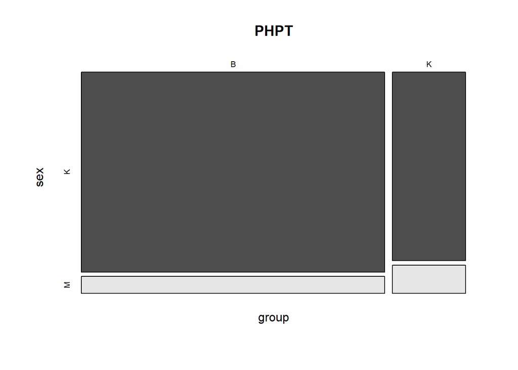

```r
mosaicplot(~ group + sex, data = PHPT, color = TRUE)
```

```r
fisher.test(table(PHPT$group, PHPT$sex))
```

```
##
##  Fisher's Exact Test for Count Data
##
## data:  table(PHPT$group, PHPT$sex)
## p-value = 0.2575
## alternative hypothesis: true odds ratio is not equal to 1
## 95 percent confidence interval:
##  0.5245141 5.1676531
## sample estimates:
## odds ratio
##   1.755183
```

```r
pairwise_fisher_test(table(PHPT$group, PHPT$sex), p.adjust.method = "fdr")
```

```
## # A tibble: 1 × 6
##   group1 group2     n     p p.adj p.adj.signif
## * <chr>  <chr>  <int> <dbl> <dbl> <chr>
## 1 B      K        237 0.258 0.258 ns
```

# proporcje kobiet do mezczyzn nie roznia sie istotnie w grupie kontrolnej i badanej

# ilosc kobiet i mezczyzn w grupie PHPT i kontrolnej:

```r
PHPT %>%
  group_by(group) %>%
  count(sex)
```

```
## # A tibble: 4 × 3
## # Groups:   group [2]
##   group sex       n
##   <chr> <chr> <int>
## 1 B     K       176
## 2 B     M        15
## 3 K     K        40
## 4 K     M         6
```

# wiek w grupie kontrolnej i grupie badanej - nie rozni sie istotnie w grupach:

```r
wilcox.test(age ~ group, data = subset(PHPT, group != "NA"))
```

```
##
##  Wilcoxon rank sum test with continuity correction
##
## data:  age by group
## W = 4382.5, p-value = 0.9809
## alternative hypothesis: true location shift is not equal to 0
```

```r
PHPT %>%
  group_by(group) %>%
  get_summary_stats(age, type = "quantile")
```

```
## # A tibble: 2 × 8
##   group variable     n  `0%` `25%` `50%` `75%` `100%`
##   <chr> <fct>    <dbl> <dbl> <dbl> <dbl> <dbl>  <dbl>
## 1 B     age        191    23  52      62  70       90
## 2 K     age         46    18  53.2    65  69.8     90
```

```r
# wieku - przy trzech grupach i rozkladnie normalnym
# model <- aov(age ~ group, PHPT)
# summary(model)
# TukeyHSD(model)
```

# BMI - grupy sa dobrane rozniez pod wzgledem BMI

```r
wilcox.test(BMI ~ group, data = subset(PHPT, group != "NA"))
```

```
##
##  Wilcoxon rank sum test with continuity correction
##
## data:  BMI by group
## W = 4135.5, p-value = 0.5381
## alternative hypothesis: true location shift is not equal to 0
```

```r
PHPT %>%
  group_by(group) %>%
  get_summary_stats(BMI, type = "quantile")
```

```
## # A tibble: 2 × 8
##   group variable     n  `0%` `25%` `50%` `75%` `100%`
##   <chr> <fct>    <dbl> <dbl> <dbl> <dbl> <dbl>  <dbl>
## 1 B     BMI        191  17.6  22.8  25.6  30.0   43.1
## 2 K     BMI         46  17.3  23.3  26.8  30.4   49.8
```

# palacze - ilos palaczy w grupie kontrolnej i badanej nie rozni sie istotnie:

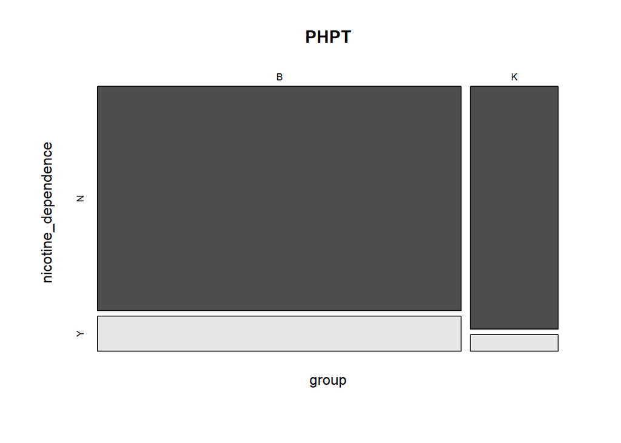

```r
mosaicplot(~ group + nicotine_dependence, data = PHPT, color = TRUE)
```

```r
fisher.test(table(PHPT$group, PHPT$nicotine_dependence))
```

```
##
##  Fisher's Exact Test for Count Data
##
## data:  table(PHPT$group, PHPT$nicotine_dependence)
## p-value = 0.2207
## alternative hypothesis: true odds ratio is not equal to 1
## 95 percent confidence interval:
##  0.08218384 1.55474736
## sample estimates:
## odds ratio
##  0.4439982
```

```r
pairwise_fisher_test(table(PHPT$group, PHPT$nicotine_dependence), p.adjust.method = "fdr")
```

```
## # A tibble: 1 × 6
##   group1 group2     n     p p.adj p.adj.signif
## * <chr>  <chr>  <int> <dbl> <dbl> <chr>
## 1 B      K        237 0.221 0.221 ns
```

```r
PHPT %>%
  group_by(group) %>%
  count(nicotine_dependence)
```

```
## # A tibble: 4 × 3
## # Groups:   group [2]
##   group nicotine_dependence     n
##   <chr> <chr>               <int>
## 1 B     N                     165
## 2 B     Y                      26
## 3 K     N                      43
## 4 K     Y                       3
```

# kamica nerkowa (nephrolithiasis) - występowanie kamicy nie rozni sie istotnie w grupie PHPT i kontrolnej:

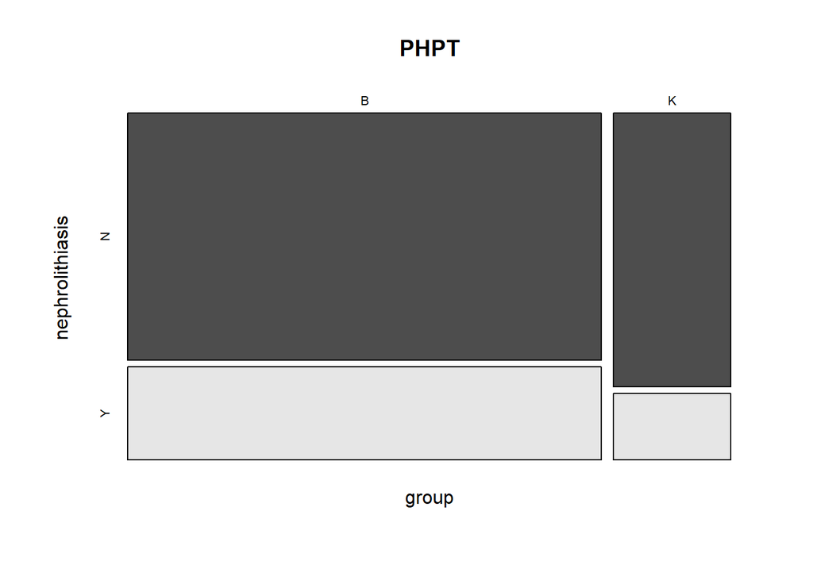

```r
mosaicplot(~ group + nephrolithiasis, data = PHPT, color = TRUE)
```

```r
fisher.test(table(PHPT$group, PHPT$nephrolithiasis))
```

```
##
##  Fisher's Exact Test for Count Data
##
## data:  table(PHPT$group, PHPT$nephrolithiasis)
## p-value = 0.3482
## alternative hypothesis: true odds ratio is not equal to 1
## 95 percent confidence interval:
##  0.2553031 1.4846100
## sample estimates:
## odds ratio
##  0.6450229
```

```r
pairwise_fisher_test(table(PHPT$group, PHPT$nephrolithiasis), p.adjust.method = "fdr")
```

```
## # A tibble: 1 × 6
##   group1 group2     n     p p.adj p.adj.signif
## * <chr>  <chr>  <int> <dbl> <dbl> <chr>
## 1 B      K        232 0.348 0.348 ns
```

```r
PHPT %>%
  group_by(group) %>%
  count(nephrolithiasis)
```

```
## # A tibble: 5 × 3
## # Groups:   group [2]
##   group nephrolithiasis     n
##   <chr> <chr>           <int>
## 1 B     N                 135
## 2 B     Y                  51
## 3 B     <NA>                5
## 4 K     N                  37
## 5 K     Y                   9
```

# objawy ze strony układu nerwowo-miesniowego (neuromuscular_symptoms) - nie roznia sie istotnie w grupie PHPT i kontrolnej:

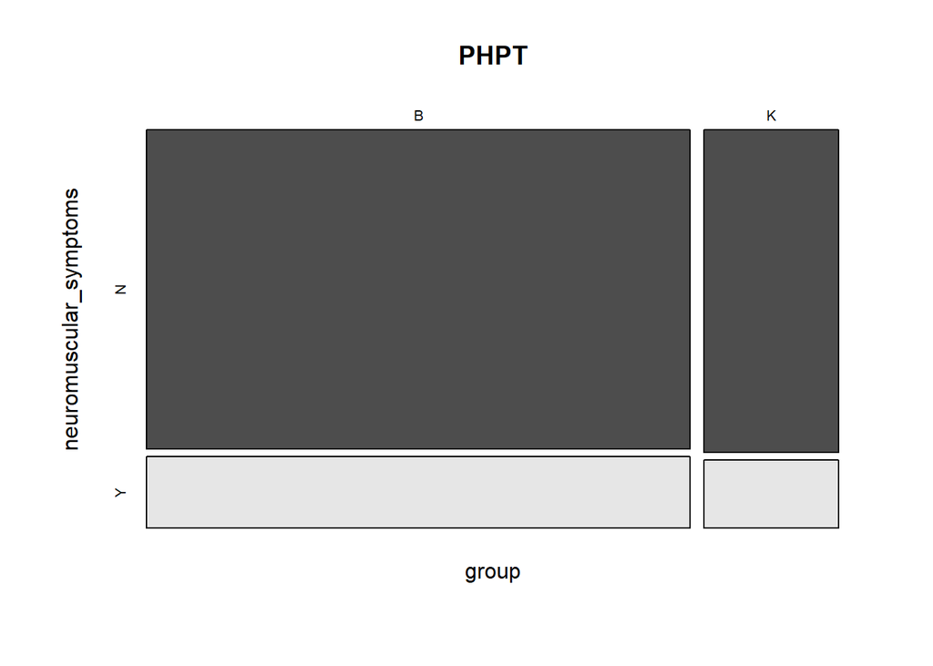

```r
mosaicplot(~ group + neuromuscular_symptoms, data = PHPT, color = TRUE)
```

```r
fisher.test(table(PHPT$group, PHPT$neuromuscular_symptoms))
```

```
##
##  Fisher's Exact Test for Count Data
##
## data:  table(PHPT$group, PHPT$neuromuscular_symptoms)
## p-value = 1
## alternative hypothesis: true odds ratio is not equal to 1
## 95 percent confidence interval:
##  0.3476952 2.2948158
## sample estimates:
## odds ratio
##  0.9414201
```

```r
pairwise_fisher_test(table(PHPT$group, PHPT$neuromuscular_symptoms), p.adjust.method = "fdr")
```

```
## # A tibble: 1 × 6
##   group1 group2     n     p p.adj p.adj.signif
## * <chr>  <chr>  <int> <dbl> <dbl> <chr>
## 1 B      K        232     1     1 ns
```

```r
PHPT %>%
  group_by(group) %>%
  count(neuromuscular_symptoms)
```

```
## # A tibble: 5 × 3
## # Groups:   group [2]
##   group neuromuscular_symptoms     n
##   <chr> <chr>                  <int>
## 1 B     N                        152
## 2 B     Y                         34
## 3 B     <NA>                       5
## 4 K     N                         38
## 5 K     Y                          8
```

# wystepowanie złamania (fracture) - nie roznilo sie istotnie statystycznie w grupie PHPT i kontrolnej:

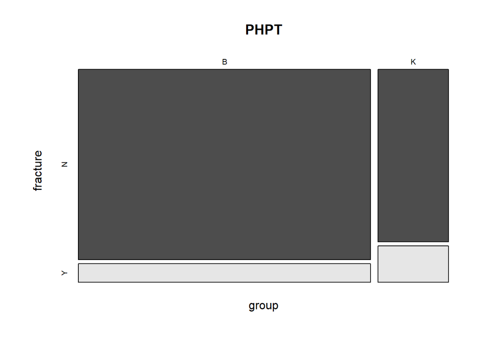

```r
mosaicplot(~ group + fracture, data = PHPT, color = TRUE)
```

```r
fisher.test(table(PHPT$group, PHPT$fracture))
```

```
##
##  Fisher's Exact Test for Count Data
##
## data:  table(PHPT$group, PHPT$fracture)
## p-value = 0.1088
## alternative hypothesis: true odds ratio is not equal to 1
## 95 percent confidence interval:
##  0.7452286 5.7255210
## sample estimates:
## odds ratio
##   2.146539
```

```r
pairwise_fisher_test(table(PHPT$group, PHPT$fracture), p.adjust.method = "fdr")
```

```
## # A tibble: 1 × 6
##   group1 group2     n     p p.adj p.adj.signif
## * <chr>  <chr>  <int> <dbl> <dbl> <chr>
## 1 B      K        237 0.109 0.109 ns
```

```r
PHPT %>%
  group_by(group) %>%
  count(fracture)
```

```
## # A tibble: 4 × 3
## # Groups:   group [2]
##   group fracture     n
##   <chr> <chr>    <int>
## 1 B     N          174
## 2 B     Y           17
## 3 K     N           38
## 4 K     Y            8
```

BADANIA LABORATORYJNE

# Ca - istotnie wyzsze stezenie w grupie PHPT

```r
wilcox.test(Ca ~ group, data = subset(PHPT, group != "NA"))
```

```
##
##  Wilcoxon rank sum test with continuity correction
##
## data:  Ca by group
## W = 8378.5, p-value < 2.2e-16
## alternative hypothesis: true location shift is not equal to 0
```

```r
PHPT %>%
  group_by(group) %>%
  get_summary_stats(Ca, type = "quantile")
```

```
## # A tibble: 2 × 8
##   group variable     n  `0%` `25%` `50%` `75%` `100%`
##   <chr> <fct>    <dbl> <dbl> <dbl> <dbl> <dbl>  <dbl>
## 1 B     Ca         191   9.4  10.4  10.7  11.3   15.5
## 2 K     Ca          46   9     9.5   9.9  10     10.5
```

# Pi - istotnie nizsze w grupie PHPT

```r
wilcox.test(Pi ~ group, data = subset(PHPT, group != "NA"))
```

```
##
##  Wilcoxon rank sum test with continuity correction
##
## data:  Pi by group
## W = 2052, p-value = 3.133e-08
## alternative hypothesis: true location shift is not equal to 0
```

```r
PHPT %>%
  group_by(group) %>%
  get_summary_stats(Pi, type = "quantile")
```

```
## # A tibble: 2 × 8
##   group variable     n  `0%` `25%` `50%` `75%` `100%`
##   <chr> <fct>    <dbl> <dbl> <dbl> <dbl> <dbl>  <dbl>
## 1 B     Pi         188   1.4   2.2   2.6   2.8    5.7
## 2 K     Pi          46   1.9   2.7   3     3.3    4
```

# iPTH - istotnie wyzsze w grupie PHPT

```r
wilcox.test(iPTH ~ group, data = subset(PHPT, group != "NA"))
```

```
##
##  Wilcoxon rank sum test with continuity correction
##
## data:  iPTH by group
## W = 7452, p-value = 4.555e-15
## alternative hypothesis: true location shift is not equal to 0
```

```r
PHPT %>%
  group_by(group) %>%
  get_summary_stats(iPTH, type = "quantile")
```

```
## # A tibble: 2 × 8
##   group variable     n  `0%` `25%` `50%` `75%` `100%`
##   <chr> <fct>    <dbl> <dbl> <dbl> <dbl> <dbl>  <dbl>
## 1 B     iPTH       189  29.4  70.9  98.7 139      922
## 2 K     iPTH        45  20.4  33.5  51.1  65.6    211
```

# 25OHD - istotnie nizsze w grupie PHPT

```r
wilcox.test(nOHD ~ group, data = subset(PHPT, group != "NA"))
```

```
##
##  Wilcoxon rank sum test with continuity correction
##
## data:  nOHD by group
## W = 2546.5, p-value = 0.0003326
## alternative hypothesis: true location shift is not equal to 0
```

```r
PHPT %>%
  group_by(group) %>%
  get_summary_stats(nOHD, type = "quantile")
```

```
## # A tibble: 2 × 8
##   group variable     n  `0%` `25%` `50%` `75%` `100%`
##   <chr> <fct>    <dbl> <dbl> <dbl> <dbl> <dbl>  <dbl>
## 1 B     nOHD       178   5.4  19.6  25.8  33.6   56
## 2 K     nOHD        44  10.6  24.8  34.4  39.4   57.5
```

# 1,25OHD - istotnie wyzsze w grupie PHPT

```r
t.test(aOHD ~ group, data = subset(PHPT, group != "NA"))
```

```
##
##  Welch Two Sample t-test
##
## data:  aOHD by group
## t = 2.8839, df = 30.171, p-value = 0.007181
## alternative hypothesis: true difference in means between group B and group K is not equal to 0
## 95 percent confidence interval:
##   4.594809 26.876986
## sample estimates:
## mean in group B mean in group K
##        71.64423        55.90833
```

```r
PHPT %>%
  group_by(group) %>%
  get_summary_stats(aOHD, type = "quantile")
```

```
## # A tibble: 2 × 8
##   group variable     n  `0%` `25%` `50%` `75%` `100%`
##   <chr> <fct>    <dbl> <dbl> <dbl> <dbl> <dbl>  <dbl>
## 1 B     aOHD        52  25.2  53.8  68.4  80.9  150
## 2 K     aOHD        12  35.1  43.8  58.3  61.5   82.3
```

# Cr - porownywalne w grupach

```r
wilcox.test(Cr ~ group, data = subset(PHPT, group != "NA"))
```

```
##
##  Wilcoxon rank sum test with continuity correction
##
## data:  Cr by group
## W = 3614.5, p-value = 0.7559
## alternative hypothesis: true location shift is not equal to 0
```

```r
PHPT %>%
  group_by(group) %>%
  get_summary_stats(Cr, type = "quantile")
```

```
## # A tibble: 2 × 8
##   group variable     n  `0%` `25%` `50%` `75%` `100%`
##   <chr> <fct>    <dbl> <dbl> <dbl> <dbl> <dbl>  <dbl>
## 1 B     Cr         182  0.49 0.673 0.765  0.88   2.1
## 2 K     Cr          41  0.57 0.69  0.78   0.86   0.99
```

# albumin - porownywanlne w grupach

```r
wilcox.test(albumin ~ group, data = subset(PHPT, group != "NA"))
```

```
##
##  Wilcoxon rank sum test with continuity correction
##
## data:  albumin by group
## W = 2398.5, p-value = 0.7826
## alternative hypothesis: true location shift is not equal to 0
```

```r
PHPT %>%
  group_by(group) %>%
  get_summary_stats(albumin, type = "quantile")
```

```
## # A tibble: 2 × 8
##   group variable     n  `0%` `25%` `50%` `75%` `100%`
##   <chr> <fct>    <dbl> <dbl> <dbl> <dbl> <dbl>  <dbl>
## 1 B     albumin    141    28    39    41    43     50
## 2 K     albumin     33    37    39    40    42     49
```

DXA

# Ryzyko złamania głównego (MOF_risk) - porownywalne w grupach badanej i kontrolnej

```r
wilcox.test(MOF_risk ~ group, data = subset(PHPT, group != "NA"))
```

```
##
##  Wilcoxon rank sum test with continuity correction
##
## data:  MOF_risk by group
## W = 4847.5, p-value = 0.2767
## alternative hypothesis: true location shift is not equal to 0
```

```r
PHPT %>%
  group_by(group) %>%
  get_summary_stats(MOF_risk, type = "quantile")
```

```
## # A tibble: 2 × 8
##   group variable     n  `0%` `25%` `50%` `75%` `100%`
##   <chr> <fct>    <dbl> <dbl> <dbl> <dbl> <dbl>  <dbl>
## 1 B     MOF_risk   191   0.4  2.3   4.2   6.75     29
## 2 K     MOF_risk    46   0.9  2.22  3.55  5.82     11
```

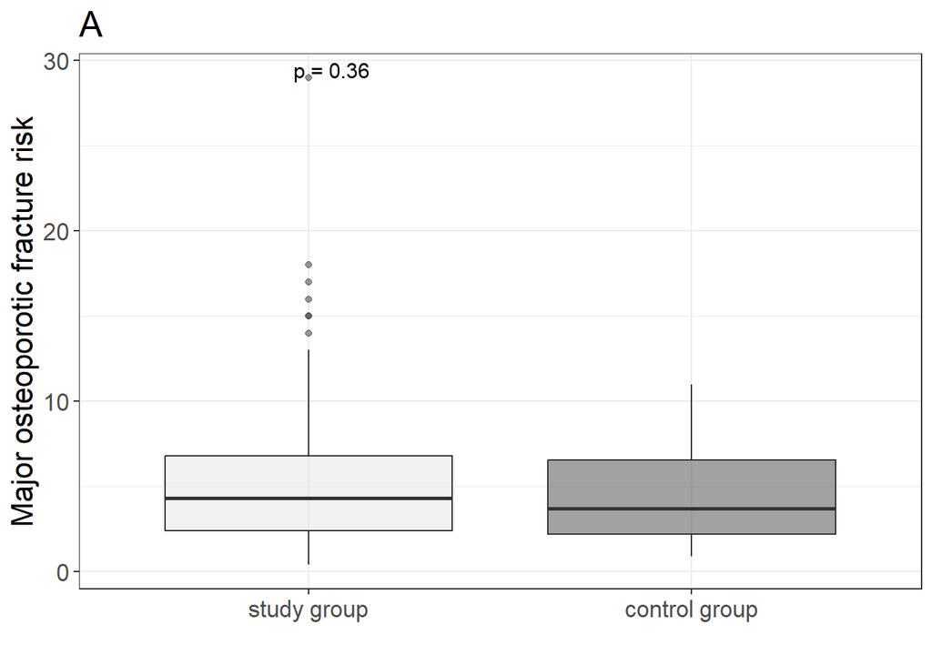

```r
# wybrane do plakatu
# wykres porownujacy MOF_risk w grupie badanej i kontrolnej:
ggplot(data = subset(PHPT, TBS != "NA"), aes(x = group, y = MOF_risk, fill = group)) +
  geom_boxplot(alpha = 0.5) +
  scale_fill_manual(values = c("gray89", "gray27"))  +
  scale_x_discrete(labels= c("study group", "control group")) +
  labs(x = " ", y = "Major osteoporotic fracture risk", title = "A") +
  stat_compare_means(method = 'wilcox.test', label = "p.format", size = 4) +
  theme_bw() +
  theme(legend.position = "none") +
  theme(text = element_text(size = 16))
```

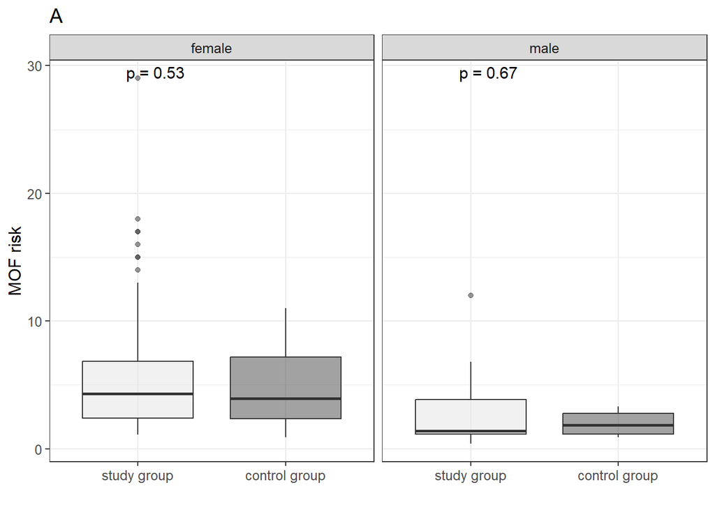

```r
# box-plot porównujący wartości MOF_risk w grupie badanej i kontrolnej z podziałem ze względu na sex
ggplot(data = subset(PHPT, MOF_risk != "NA"), aes(x = group, y = MOF_risk, fill = group)) +
  geom_boxplot(alpha = 0.5) +
  scale_fill_manual(values = c("gray89", "gray27"))  +
  scale_x_discrete(labels= c("study group", "control group")) +
  labs(x = " ", y = "MOF risk", title = 'A') +
  stat_compare_means(method = 'wilcox.test', label = "p.format", size = 4) +
  theme_bw() +
  theme(legend.position = "none") +
  facet_wrap(vars(sex), labeller = labeller(sex = c('K' = 'female', 'M' = 'male'))) +
  theme(text = element_text(size = 12))
```

# Ryzyko złamania biodra (HF_risk) - porownywalne:

```r
wilcox.test(HF_risk ~ group, data = subset(PHPT, group != "NA"))
```

```
##
##  Wilcoxon rank sum test with continuity correction
##
## data:  HF_risk by group
## W = 4944.5, p-value = 0.1855
## alternative hypothesis: true location shift is not equal to 0
```

```r
PHPT %>%
  group_by(group) %>%
  get_summary_stats(HF_risk, type = "quantile")
```

```
## # A tibble: 2 × 8
##   group variable     n  `0%` `25%` `50%` `75%` `100%`
##   <chr> <fct>    <dbl> <dbl> <dbl> <dbl> <dbl>  <dbl>
## 1 B     HF_risk    191     0 0.2     0.7   1.9   22
## 2 K     HF_risk     46     0 0.125   0.5   1.5    4.7
```

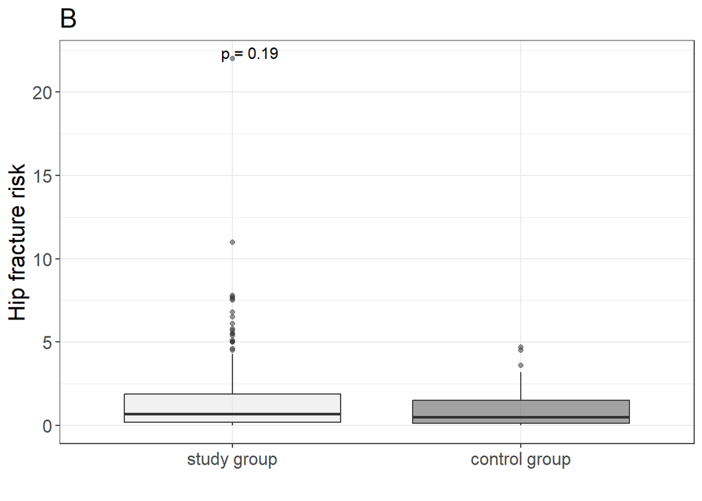

```r
# wykres porownujacy HF_risk w grupie badanej i kontrolnej:
ggplot(data = subset(PHPT, HF_risk != "NA"), aes(x = group, y = HF_risk, fill = group)) +
  geom_boxplot(alpha = 0.5) +
  scale_fill_manual(values = c("gray89", "gray27"))  +
  scale_x_discrete(labels= c("study group", "control group")) +
  labs(x = " ", y = "Hip fracture risk", title = "B") +
  stat_compare_means(method = 'wilcox.test', label = "p.format", size = 4) +
  theme_bw() +
  theme(legend.position = "none") +
  theme(text = element_text(size = 16))
```

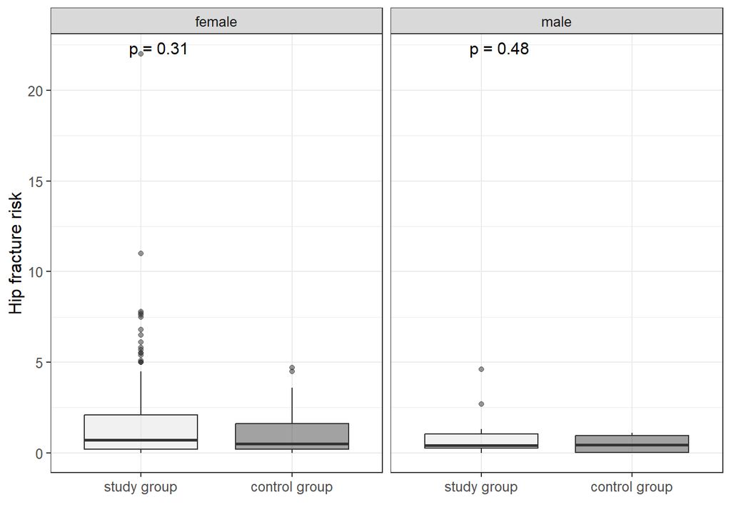

```r
# box-plot porównujący wartości HF_risk w grupie badanej i kontrolnej z podziałem ze względu na sex
ggplot(data = subset(PHPT, HF_risk != "NA"), aes(x = group, y = HF_risk, fill = group)) +
  geom_boxplot(alpha = 0.5) +
  scale_fill_manual(values = c("gray89", "gray27"))  +
  scale_x_discrete(labels= c("study group", "control group")) +
  labs(x = " ", y = "Hip fracture risk") +
  stat_compare_means(method = 'wilcox.test', label = "p.format", size = 4) +
  theme_bw() +
  theme(legend.position = "none") +
  facet_wrap(vars(sex), labeller = labeller(sex = c('K' = 'female', 'M' = 'male'))) +
  theme(text = element_text(size = 12))
```

# Gestosc mineralna szyjki kosci udowej (BMD_neck)

# porownanie miedzy grupa PHPT a kontrolną:

```r
wilcox.test(BMD_neck ~ group, data = subset(PHPT, group != "NA"))
```

```
##
##  Wilcoxon rank sum test with continuity correction
##
## data:  BMD_neck by group
## W = 3585, p-value = 0.07272
## alternative hypothesis: true location shift is not equal to 0
```

```r
PHPT %>%
  group_by(group) %>%
  get_summary_stats(BMD_neck, type = "quantile")
```

```
## # A tibble: 2 × 8
##   group variable     n  `0%` `25%` `50%` `75%` `100%`
##   <chr> <fct>    <dbl> <dbl> <dbl> <dbl> <dbl>  <dbl>
## 1 B     BMD_neck   188 0.407 0.608 0.709 0.778   1.15
## 2 K     BMD_neck    46 0.553 0.648 0.732 0.804   1.14
```

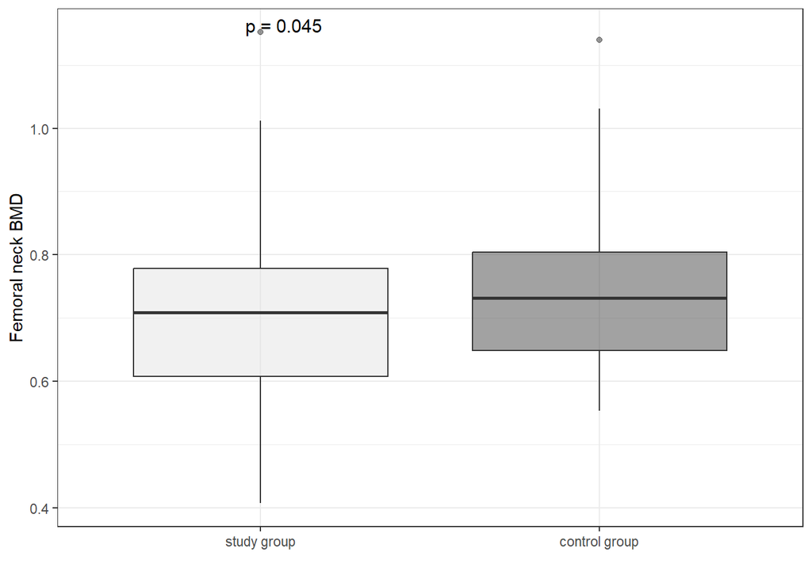

```r
# box-plot porównujący wartości BMD neck w grupie badanej i kontrolnej
ggplot(PHPT, aes(x = group, y = BMD_neck, fill = group)) +
  geom_boxplot(alpha = 0.5) +
  scale_fill_manual(values = c("gray89", "gray27"))  +
  scale_x_discrete(labels= c("study group", "control group")) +
  labs(x = " ", y = "Femoral neck BMD") +
  stat_compare_means(method = 't.test', label = "p.format", size = 4) +
  theme_bw() +
  theme(legend.position = "none")
```

# porównanie wartości BMD neck u kobiet i mezczyzn w grupie badanej i kontrolnej

```r
# porównanie wartości BMD neck u kobiet w grupie badanej i kontrolnej
wilcox.test(BMD_neck ~ group, data = subset(PHPT, sex == 'K'))
```

```
##
##  Wilcoxon rank sum test with continuity correction
##
## data:  BMD_neck by group
## W = 2947.5, p-value = 0.145
## alternative hypothesis: true location shift is not equal to 0
```

```r
# porównanie wartości BMD neck u mezczyzn w grupie badanej i kontrolnej
wilcox.test(BMD_neck ~ group, data = subset(PHPT, sex == 'M'))
```

```
##
##  Wilcoxon rank sum test with continuity correction
##
## data:  BMD_neck by group
## W = 37.5, p-value = 0.5857
## alternative hypothesis: true location shift is not equal to 0
```

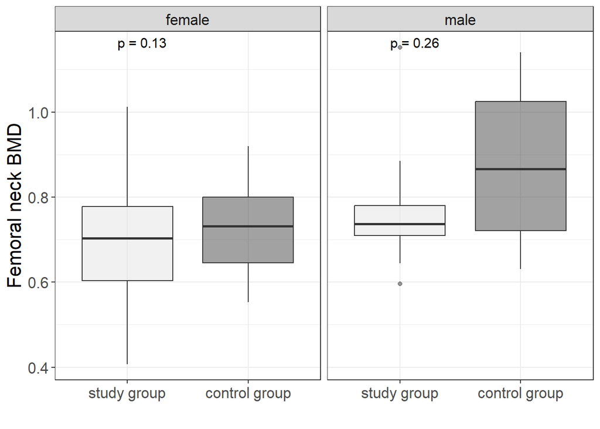

```r
# WYBRANE DO PLAKATU
# box-plot porównujący wartości BMD neck w grupie badanej i kontrolnej z podziałem ze względu na sex
ggplot(PHPT, aes(x = group, y = BMD_neck, fill = group)) +
  geom_boxplot(alpha = 0.5) +
  scale_fill_manual(values = c("gray89", "gray27"))  +
  scale_x_discrete(labels= c("study group", "control group")) +
  labs(x = " ", y = "Femoral neck BMD") +
  stat_compare_means(method = 't.test', label = "p.format", size = 4) +
  theme_bw() +
  theme(legend.position = "none") +
  facet_wrap(vars(sex), labeller = labeller(sex = c('K' = 'female', 'M' = 'male'))) +
  theme(text = element_text(size = 16))
```

# box-plot porównujący wartości BMD neck w grupie badanej i kontrolnej z podziałem ze względu na sex i na zlamania

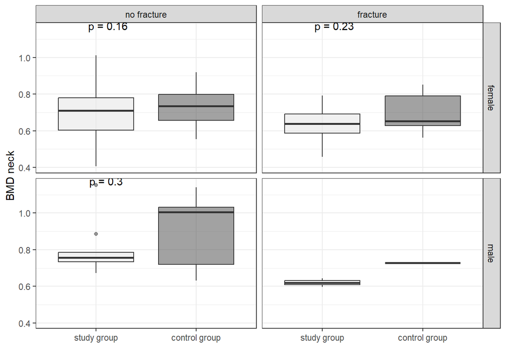

```r
ggplot(data = subset(PHPT, fracture != "NA"), aes(x = group, y = BMD_neck, fill = group)) +
  geom_boxplot(alpha = 0.5) +
  scale_fill_manual(values = c("gray89", "gray27"))  +
  labs(x = " ", y = "BMD neck") +
  stat_compare_means(label = "p.format", method = 't.test') +
  theme_bw()  +
  theme(legend.position = "none") +
  scale_x_discrete(labels= c("study group", "control group")) +
  facet_grid(sex ~ fracture,
             labeller = labeller(
               sex = c('K' = 'female', 'M' = 'male'),
               fracture = c('N' = 'no fracture', 'Y' = 'fracture')
             ))
```

# Tscore_lumbar

```r
t.test(Tscore_lumbar ~ group, data = subset(PHPT, group != "NA"))
```

```
##
##  Welch Two Sample t-test
##
## data:  Tscore_lumbar by group
## t = -2.147, df = 52.404, p-value = 0.03644
## alternative hypothesis: true difference in means between group B and group K is not equal to 0
## 95 percent confidence interval:
##  -1.05514702 -0.03574914
## sample estimates:
## mean in group B mean in group K
##       -1.518421       -0.972973
```

```r
PHPT %>%
  group_by(group) %>%
  get_summary_stats(Tscore_lumbar, type = "common")
```

```
## # A tibble: 2 × 11
##   group variable          n   min   max median   iqr   mean    sd    se    ci
##   <chr> <fct>         <dbl> <dbl> <dbl>  <dbl> <dbl>  <dbl> <dbl> <dbl> <dbl>
## 1 B     Tscore_lumbar   152  -4.9   2     -1.5  1.72 -1.52   1.31 0.106 0.21
## 2 K     Tscore_lumbar    37  -3.5   1.5   -1.2  1.9  -0.973  1.40 0.231 0.468
```

# wykres porownujacy Tscore_lumbar w grupie badanej i kontrolnej:

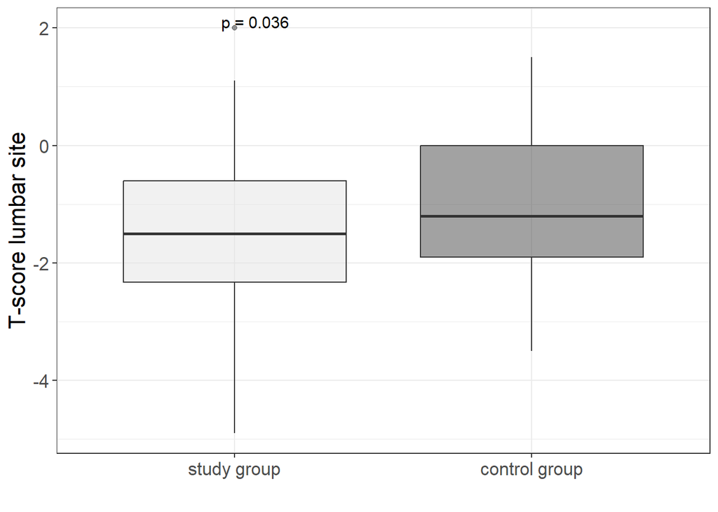

```r
ggplot(PHPT, aes(x = group, y = Tscore_lumbar, fill = group)) +
  geom_boxplot(alpha = 0.5) +
  scale_fill_manual(values = c("gray89", "gray27"))  +
  scale_x_discrete(labels= c("study group", "control group")) +
  labs(x = " ", y = "T-score lumbar site") +
  stat_compare_means(method = 't.test', label = "p.format", size = 4) +
  theme_bw() +
  theme(legend.position = "none") +
  theme(text = element_text(size = 16))
```

# wykres porownujacy Tscore_lumbar w grupie badanej i kontrolnej:

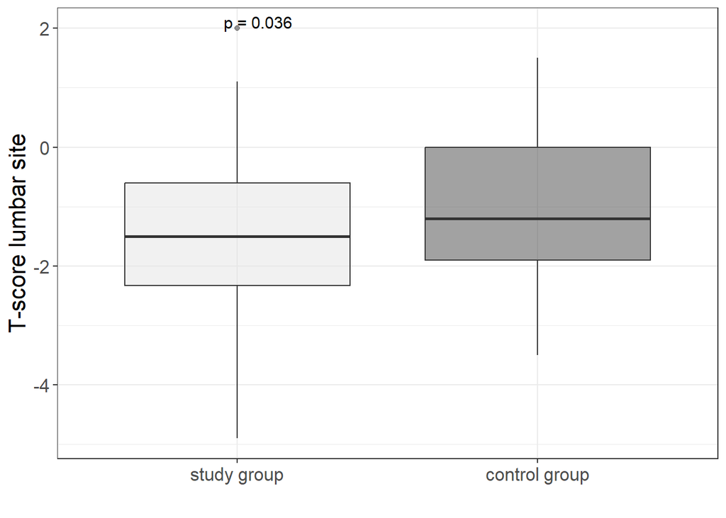

```r
ggplot(PHPT, aes(x = group, y = Tscore_lumbar, fill = group)) +
  geom_boxplot(alpha = 0.5) +
  scale_fill_manual(values = c("gray89", "gray27"))  +
  scale_x_discrete(labels= c("study group", "control group")) +
  labs(x = " ", y = "T-score lumbar site") +
  stat_compare_means(method = 't.test', label = "p.format", size = 4) +
  theme_bw() +
  theme(legend.position = "none") +
  theme(text = element_text(size = 16))
```

# T_score_lumbar z podziałem ze względu na sex

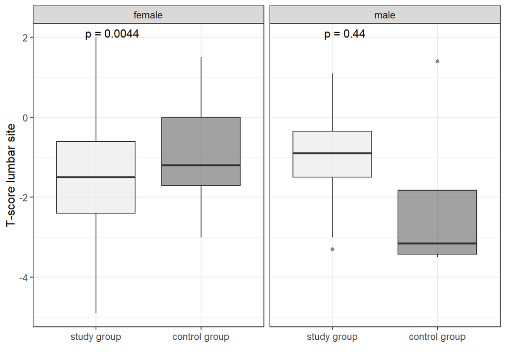

```r
ggplot(PHPT, aes(x = group, y = Tscore_lumbar, fill = group)) +
  geom_boxplot(alpha = 0.5) +
  scale_fill_manual(values = c("gray89", "gray27"))  +
  scale_x_discrete(labels= c("study group", "control group")) +
  labs(x = " ", y = "T-score lumbar site") +
  stat_compare_means(method = 't.test', label = "p.format", size = 4) +
  theme_bw() +
  theme(legend.position = "none") +
  facet_wrap(vars(sex), labeller = labeller(sex = c('K' = 'female', 'M' = 'male'))) +
  theme(text = element_text(size = 12))
```

# T_score _lumbar z podziałem ze względu na wiek

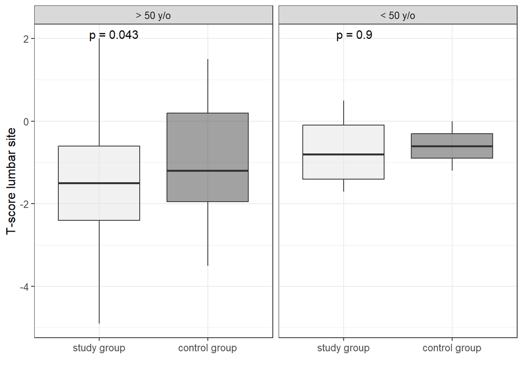

```r
ggplot(PHPT, aes(x = group, y = Tscore_lumbar, fill = group)) +
  geom_boxplot(alpha = 0.5) +
  scale_fill_manual(values = c("gray89", "gray27"))  +
  scale_x_discrete(labels= c("study group", "control group")) +
  labs(x = " ", y = "T-score lumbar site") +
  stat_compare_means(method = 't.test', label = "p.format", size = 4) +
  theme_bw() +
  theme(legend.position = "none") +
  facet_wrap(vars(age_split), labeller = labeller(age_split = c('older' = '> 50 y/o', 'younger' = '< 50 y/o'))) +
  theme(text = element_text(size = 12))
```

# T_score _lumbar z podziałem ze względu na płeć i wiek

```r
PHPT %>%
  filter(sex == "K", !is.na(group)) %>%
  t.test(Tscore_lumbar ~ group, data = .)
```

```
##
##  Welch Two Sample t-test
##
## data:  Tscore_lumbar by group
## t = -2.9821, df = 50.359, p-value = 0.004403
## alternative hypothesis: true difference in means between group B and group K is not equal to 0
## 95 percent confidence interval:
##  -1.2042951 -0.2350343
## sample estimates:
## mean in group B mean in group K
##      -1.5560284      -0.8363636
```

```r
PHPT %>%
  filter(sex == "K") %>%
  group_by(group) %>%
  get_summary_stats(Tscore_lumbar, type = "common")
```

```
## # A tibble: 2 × 11
##   group variable          n   min   max median   iqr   mean    sd    se    ci
##   <chr> <fct>         <dbl> <dbl> <dbl>  <dbl> <dbl>  <dbl> <dbl> <dbl> <dbl>
## 1 B     Tscore_lumbar   141  -4.9   2     -1.5   1.8 -1.56   1.31 0.11  0.218
## 2 K     Tscore_lumbar    33  -3     1.5   -1.2   1.7 -0.836  1.23 0.215 0.437
```

```r
PHPT %>%
  filter(sex == "M", !is.na(group)) %>%
  t.test(Tscore_lumbar ~ group, data = .)
```

```
##
##  Welch Two Sample t-test
##
## data:  Tscore_lumbar by group
## t = 0.85923, df = 3.6942, p-value = 0.4424
## alternative hypothesis: true difference in means between group B and group K is not equal to 0
## 95 percent confidence interval:
##  -2.488465  4.615738
## sample estimates:
## mean in group B mean in group K
##       -1.036364       -2.100000
```

```r
PHPT %>%
  filter(sex == "M") %>%
  group_by(group) %>%
  get_summary_stats(Tscore_lumbar, type = "common")
```

```
## # A tibble: 2 × 11
##   group variable          n   min   max median   iqr  mean    sd    se    ci
##   <chr> <fct>         <dbl> <dbl> <dbl>  <dbl> <dbl> <dbl> <dbl> <dbl> <dbl>
## 1 B     Tscore_lumbar    11  -3.3   1.1  -0.9   1.15 -1.04  1.30 0.392 0.875
## 2 K     Tscore_lumbar     4  -3.5   1.4  -3.15  1.6  -2.1   2.35 1.17  3.74
```

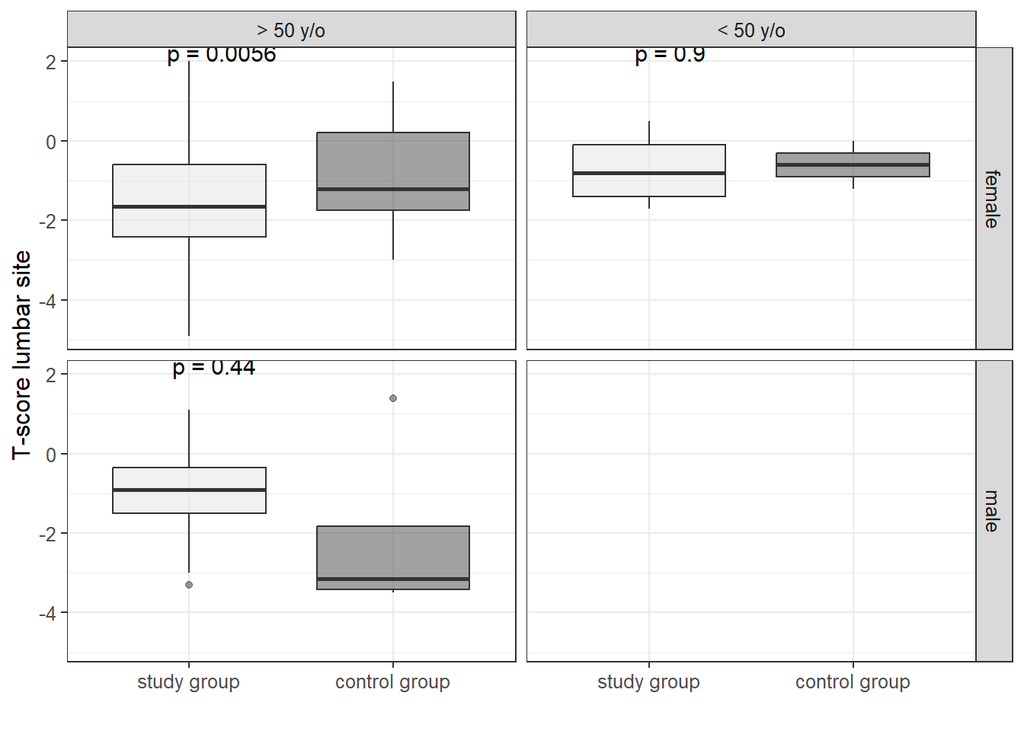

```r
ggplot(PHPT, aes(x = group, y = Tscore_lumbar, fill = group)) +
  geom_boxplot(alpha = 0.5) +
  scale_fill_manual(values = c("gray89", "gray27"))  +
  scale_x_discrete(labels= c("study group", "control group")) +
  labs(x = " ", y = "T-score lumbar site") +
  stat_compare_means(method = 't.test', label = "p.format", size = 4) +
  theme_bw() +
  theme(legend.position = "none") +
  facet_grid(sex ~ age_split,
             labeller = labeller(
               sex = c('K' = 'female', 'M' = 'male'),
               age_split = c('older' = '> 50 y/o', 'younger' = '< 50 y/o')
             )) +
  theme(text = element_text(size = 12))
```

# Tscore_femur_neck

```r
t.test(Tscore_femur_neck ~ group, data = subset(PHPT, group != "NA"))
```

```
##
##  Welch Two Sample t-test
##
## data:  Tscore_femur_neck by group
## t = -1.8167, df = 54.505, p-value = 0.07477
## alternative hypothesis: true difference in means between group B and group K is not equal to 0
## 95 percent confidence interval:
##  -0.65882687  0.03237714
## sample estimates:
## mean in group B mean in group K
##       -1.560284       -1.247059
```

```r
PHPT %>%
  group_by(group) %>%
  get_summary_stats(Tscore_femur_neck, type = "common")
```

```
## # A tibble: 2 × 11
##   group variable              n   min   max median   iqr  mean    sd    se    ci
##   <chr> <fct>             <dbl> <dbl> <dbl>  <dbl> <dbl> <dbl> <dbl> <dbl> <dbl>
## 1 B     Tscore_femur_neck   141  -4     1.5   -1.6  1.4  -1.56 0.982 0.083 0.163
## 2 K     Tscore_femur_neck    34  -2.7   0.7   -1.2  1.35 -1.25 0.882 0.151 0.308
```

# Tscore_femur_neck z podziałem ze względu na płeć i wiek

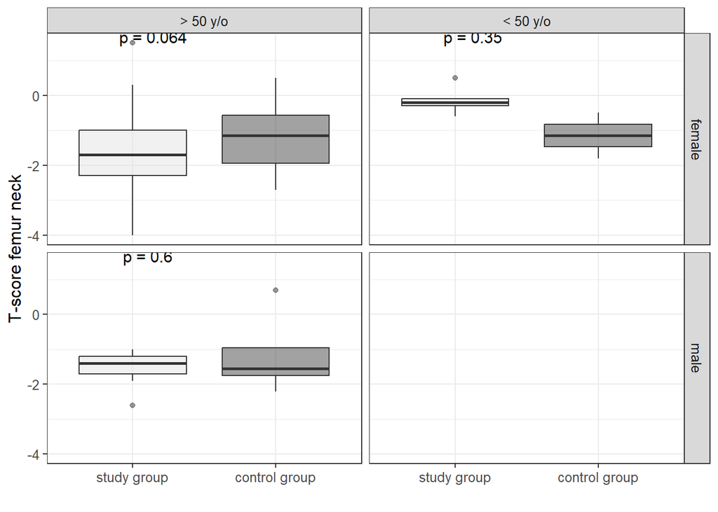

```r
ggplot(PHPT, aes(x = group, y = Tscore_femur_neck, fill = group)) +
  geom_boxplot(alpha = 0.5) +
  scale_fill_manual(values = c("gray89", "gray27"))  +
  scale_x_discrete(labels= c("study group", "control group")) +
  labs(x = " ", y = "T-score femur neck") +
  stat_compare_means(method = 't.test', label = "p.format", size = 4) +
  theme_bw() +
  theme(legend.position = "none") +
  facet_grid(sex ~ age_split,
             labeller = labeller(
               sex = c('K' = 'female', 'M' = 'male'),
               age_split = c('older' = '> 50 y/o', 'younger' = '< 50 y/o')
             )) +
  theme(text = element_text(size = 12))
```

# Tscore_radial

```r
t.test(Tscore_radial ~ group, data = subset(PHPT, group != "NA"))
```

```
##
##  Welch Two Sample t-test
##
## data:  Tscore_radial by group
## t = -3.165, df = 57.148, p-value = 0.002486
## alternative hypothesis: true difference in means between group B and group K is not equal to 0
## 95 percent confidence interval:
##  -1.3910686 -0.3129942
## sample estimates:
## mean in group B mean in group K
##       -2.114194       -1.262162
```

```r
PHPT %>%
  group_by(group) %>%
  get_summary_stats(Tscore_radial, type = "common")
```

```
## # A tibble: 2 × 11
##   group variable          n   min   max median   iqr  mean    sd    se    ci
##   <chr> <fct>         <dbl> <dbl> <dbl>  <dbl> <dbl> <dbl> <dbl> <dbl> <dbl>
## 1 B     Tscore_radial   155  -6.5   1.8   -2     2.3 -2.11  1.55 0.124 0.245
## 2 K     Tscore_radial    37  -4.3   1     -1.5   2.3 -1.26  1.45 0.239 0.484
```

```r
PHPT %>%
  filter(sex == "K", !is.na(group)) %>%
  t.test(Tscore_radial ~ group, data = .)
```

```
##
##  Welch Two Sample t-test
##
## data:  Tscore_radial by group
## t = -2.8764, df = 49.227, p-value = 0.00593
## alternative hypothesis: true difference in means between group B and group K is not equal to 0
## 95 percent confidence interval:
##  -1.407640 -0.249809
## sample estimates:
## mean in group B mean in group K
##       -2.125694       -1.296970
```

```r
PHPT %>%
  filter(sex == "K") %>%
  group_by(group) %>%
  get_summary_stats(Tscore_radial, type = "common")
```

```
## # A tibble: 2 × 11
##   group variable          n   min   max median   iqr  mean    sd    se    ci
##   <chr> <fct>         <dbl> <dbl> <dbl>  <dbl> <dbl> <dbl> <dbl> <dbl> <dbl>
## 1 B     Tscore_radial   144  -6.5   1.8  -2.15   2.3 -2.13  1.54 0.129 0.254
## 2 K     Tscore_radial    33  -4.3   0.9  -1.5    2.4 -1.30  1.48 0.258 0.525
```

```r
PHPT %>%
  filter(sex == "M", !is.na(group)) %>%
  t.test(Tscore_radial ~ group, data = .)
```

```
##
##  Welch Two Sample t-test
##
## data:  Tscore_radial by group
## t = -1.1803, df = 6.6529, p-value = 0.2784
## alternative hypothesis: true difference in means between group B and group K is not equal to 0
## 95 percent confidence interval:
##  -2.990401  1.013128
## sample estimates:
## mean in group B mean in group K
##       -1.963636       -0.975000
```

```r
PHPT %>%
  filter(sex == "M") %>%
  group_by(group) %>%
  get_summary_stats(Tscore_radial, type = "common")
```

```
## # A tibble: 2 × 11
##   group variable          n   min   max median   iqr   mean    sd    se    ci
##   <chr> <fct>         <dbl> <dbl> <dbl>  <dbl> <dbl>  <dbl> <dbl> <dbl> <dbl>
## 1 B     Tscore_radial    11  -4.9   0.6  -1.9  1.45  -1.96   1.66 0.501  1.12
## 2 K     Tscore_radial     4  -2     1    -1.45 0.825 -0.975  1.34 0.671  2.14
```

# PORÓWNANIE T-score radial pomiedzy grupa badaną a kontrolną

# wykres porownujacy Tscore_radial w grupie badanej i kontrolnej:

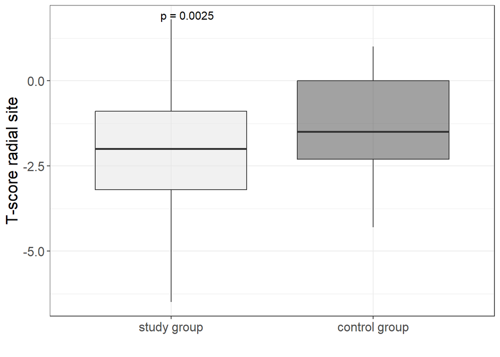

```r
ggplot(PHPT, aes(x = group, y = Tscore_radial, fill = group)) +
  geom_boxplot(alpha = 0.5) +
  scale_fill_manual(values = c("gray89", "gray27"))  +
  scale_x_discrete(labels= c("study group", "control group")) +
  labs(x = " ", y = "T-score radial site") +
  stat_compare_means(method = 't.test', label = "p.format", size = 4) +
  theme_bw() +
  theme(legend.position = "none") +
  theme(text = element_text(size = 16))
```

# wykres porownujacy Tscore_radial w grupie badanej i kontrolnej z podziałem ze względu na płeć:

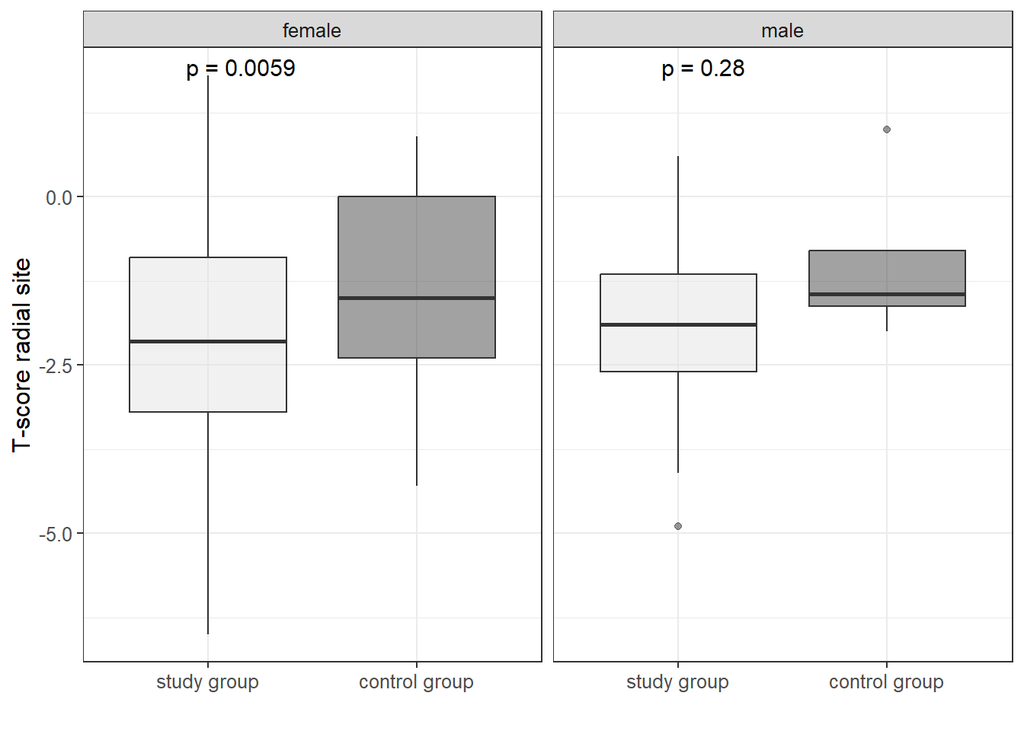

```r
ggplot(PHPT, aes(x = group, y = Tscore_radial, fill = group)) +
  geom_boxplot(alpha = 0.5) +
  scale_fill_manual(values = c("gray89", "gray27"))  +
  scale_x_discrete(labels= c("study group", "control group")) +
  labs(x = " ", y = "T-score radial site") +
  stat_compare_means(method = 't.test', label = "p.format", size = 4) +
  theme_bw() +
  theme(legend.position = "none") +
  facet_wrap(vars(sex), labeller = labeller(sex = c('K' = 'female', 'M' = 'male'))) +
  theme(text = element_text(size = 12))
```

# Tscore_radial w grupie PHPT i kontrolnej z podziałem ze względu na płeć i wiek

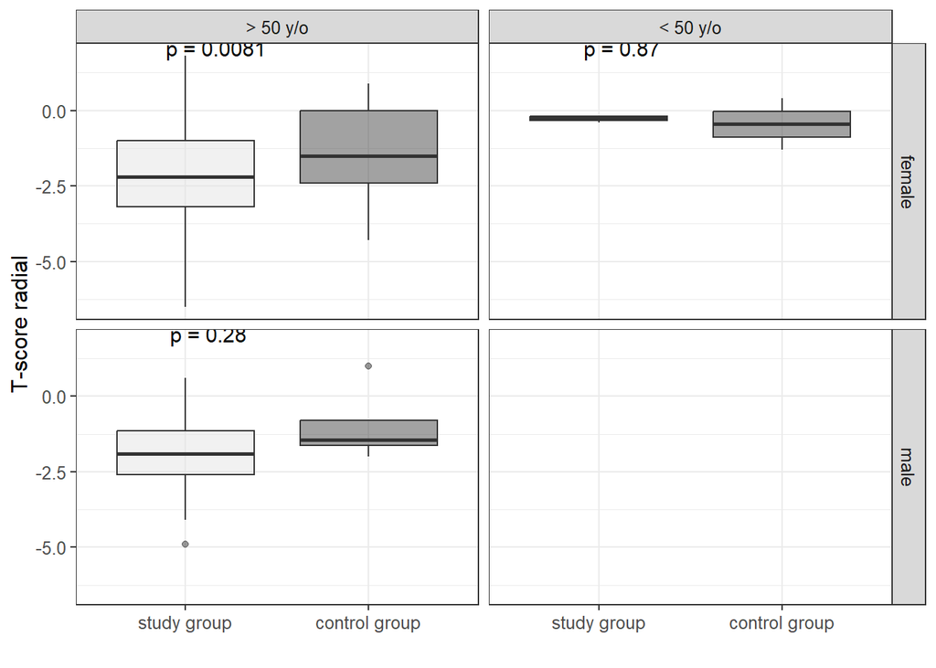

```r
ggplot(PHPT, aes(x = group, y = Tscore_radial, fill = group)) +
  geom_boxplot(alpha = 0.5) +
  scale_fill_manual(values = c("gray89", "gray27"))  +
  scale_x_discrete(labels= c("study group", "control group")) +
  labs(x = " ", y = "T-score radial") +
  stat_compare_means(method = 't.test', label = "p.format", size = 4) +
  theme_bw() +
  theme(legend.position = "none") +
  facet_grid(sex ~ age_split,
             labeller = labeller(
               sex = c('K' = 'female', 'M' = 'male'),
               age_split = c('older' = '> 50 y/o', 'younger' = '< 50 y/o')
             )) +
  theme(text = element_text(size = 12))
```

# zscore_lumbar

```r
t.test(zscore_lumbar ~ group, data = subset(PHPT, group != "NA"))
```

```
##
##  Welch Two Sample t-test
##
## data:  zscore_lumbar by group
## t = -1.8482, df = 61.61, p-value = 0.06937
## alternative hypothesis: true difference in means between group B and group K is not equal to 0
## 95 percent confidence interval:
##  -1.0148319  0.0398319
## sample estimates:
## mean in group B mean in group K
##     -0.02228261      0.46521739
```

```r
PHPT %>%
  group_by(group) %>%
  get_summary_stats(zscore_lumbar, type = "common")
```

```
## # A tibble: 2 × 11
##   group variable          n   min   max median   iqr   mean    sd    se    ci
##   <chr> <fct>         <dbl> <dbl> <dbl>  <dbl> <dbl>  <dbl> <dbl> <dbl> <dbl>
## 1 B     zscore_lumbar   184  -3.6   4.5  -0.05  1.6  -0.022  1.38 0.102 0.201
## 2 K     zscore_lumbar    46  -3.1   3.3   0.55  1.75  0.465  1.65 0.243 0.49
```

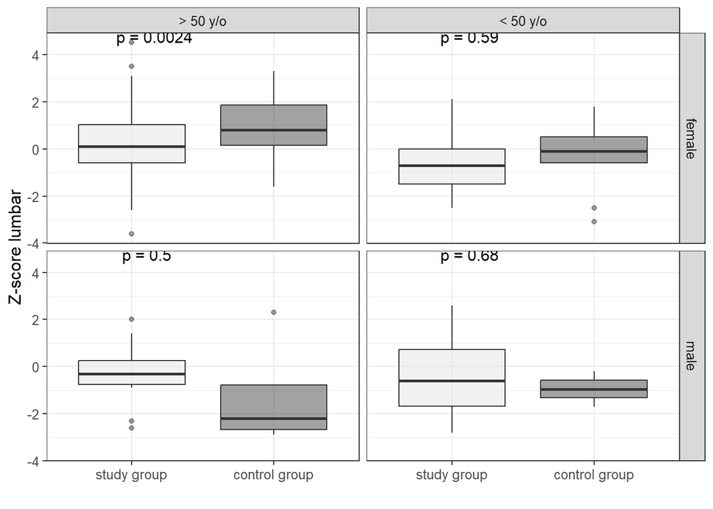

```r
ggplot(PHPT, aes(x = group, y = zscore_lumbar, fill = group)) +
  geom_boxplot(alpha = 0.5) +
  scale_fill_manual(values = c("gray89", "gray27"))  +
  scale_x_discrete(labels= c("study group", "control group")) +
  labs(x = " ", y = "Z-score lumbar") +
  stat_compare_means(method = 't.test', label = "p.format", size = 4) +
  theme_bw() +
  theme(legend.position = "none") +
  facet_grid(sex ~ age_split,
             labeller = labeller(
               sex = c('K' = 'female', 'M' = 'male'),
               age_split = c('older' = '> 50 y/o', 'younger' = '< 50 y/o')
             )) +
  theme(text = element_text(size = 12))
```

# zscore_femur_neck

```r
t.test(zscore_femur_neck ~ group, data = subset(PHPT, group != "NA"))
```

```
##
##  Welch Two Sample t-test
##
## data:  zscore_femur_neck by group
## t = -1.6221, df = 57.375, p-value = 0.1103
## alternative hypothesis: true difference in means between group B and group K is not equal to 0
## 95 percent confidence interval:
##  -0.65799134  0.06901017
## sample estimates:
## mean in group B mean in group K
##      -0.1563953       0.1380952
```

```r
PHPT %>%
  group_by(group) %>%
  get_summary_stats(zscore_femur_neck, type = "common")
```

```
## # A tibble: 2 × 11
##   group variable             n   min   max median   iqr   mean    sd    se    ci
##   <chr> <fct>            <dbl> <dbl> <dbl>  <dbl> <dbl>  <dbl> <dbl> <dbl> <dbl>
## 1 B     zscore_femur_ne…   172  -3     3.1  -0.3   1.2  -0.156 0.947 0.072 0.143
## 2 K     zscore_femur_ne…    42  -1.9   2     0.05  1.55  0.138 1.08  0.167 0.336
```

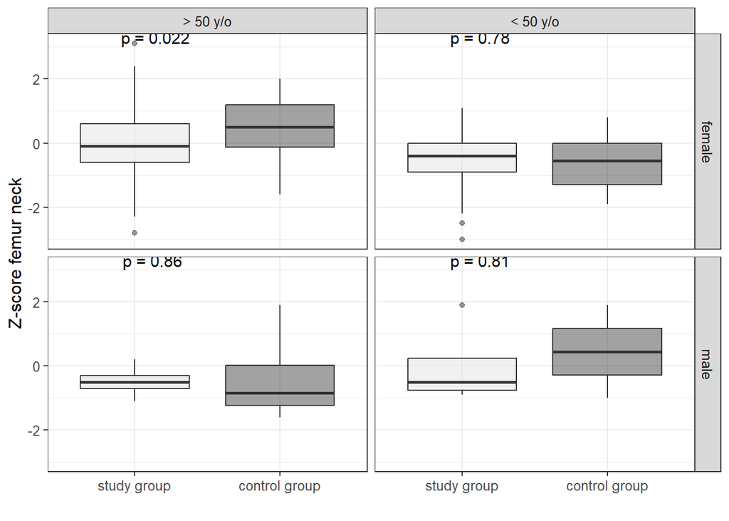

```r
ggplot(PHPT, aes(x = group, y = zscore_femur_neck, fill = group)) +
  geom_boxplot(alpha = 0.5) +
  scale_fill_manual(values = c("gray89", "gray27"))  +
  scale_x_discrete(labels= c("study group", "control group")) +
  labs(x = " ", y = "Z-score femur neck") +
  stat_compare_means(method = 't.test', label = "p.format", size = 4) +
  theme_bw() +
  theme(legend.position = "none") +
  facet_grid(sex ~ age_split,
             labeller = labeller(
               sex = c('K' = 'female', 'M' = 'male'),
               age_split = c('older' = '> 50 y/o', 'younger' = '< 50 y/o')
             )) +
  theme(text = element_text(size = 12))
```

# zscore_radial

```r
t.test(zscore_radial ~ group, data = subset(PHPT, group != "NA"))
```

```
##
##  Welch Two Sample t-test
##
## data:  zscore_radial by group
## t = -3.6478, df = 66.88, p-value = 0.0005189
## alternative hypothesis: true difference in means between group B and group K is not equal to 0
## 95 percent confidence interval:
##  -1.2116153 -0.3545856
## sample estimates:
## mean in group B mean in group K
##      -0.2711957       0.5119048
```

```r
PHPT %>%
  group_by(group) %>%
  get_summary_stats(zscore_radial, type = "common")
```

```
## # A tibble: 2 × 11
##   group variable          n   min   max median   iqr   mean    sd    se    ci
##   <chr> <fct>         <dbl> <dbl> <dbl>  <dbl> <dbl>  <dbl> <dbl> <dbl> <dbl>
## 1 B     zscore_radial   184  -4.2   2.9  -0.3   1.8  -0.271  1.38 0.102 0.201
## 2 K     zscore_radial    42  -2.1   2.6   0.45  1.75  0.512  1.23 0.189 0.382
```

# PORÓWNANIE z-score radial pomiędzy grupą badaną a kontrolną

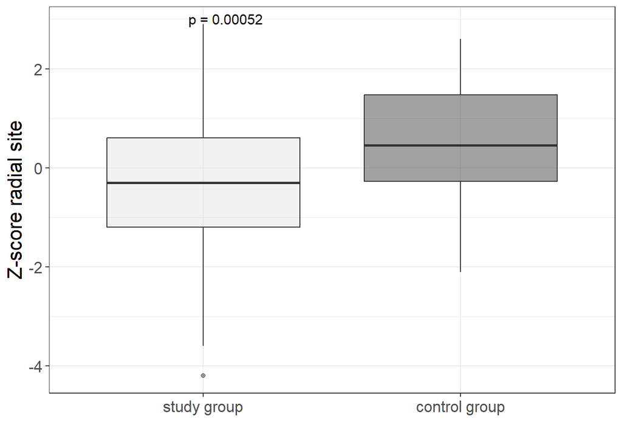

```r
ggplot(PHPT, aes(x = group, y = zscore_radial, fill = group)) +
  geom_boxplot(alpha = 0.5) +
  scale_fill_manual(values = c("gray89", "gray27"))  +
  scale_x_discrete(labels= c("study group", "control group")) +
  labs(x = " ", y = "Z-score radial site") +
  stat_compare_means(method = 't.test', label = "p.format", size = 4) +
  theme_bw() +
  theme(legend.position = "none") +
  theme(text = element_text(size = 16))
```

# PORÓWNANIE z-score radial pomiędzy grupą badaną a kontrolną z podziałem ze względu na płeć:

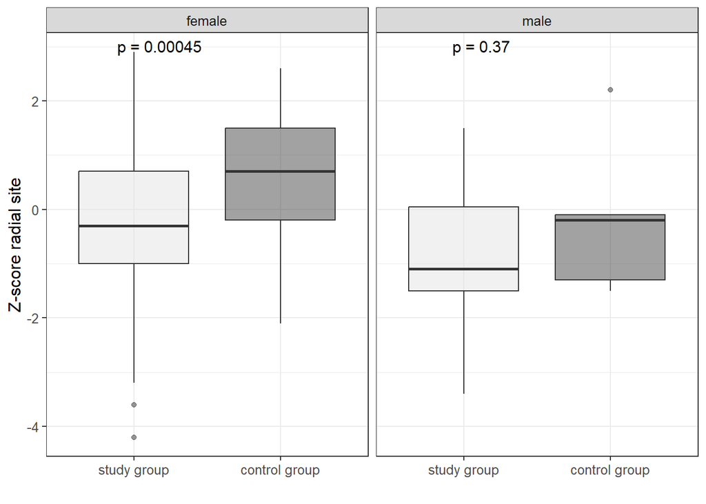

```r
ggplot(PHPT, aes(x = group, y = zscore_radial, fill = group)) +
  geom_boxplot(alpha = 0.5) +
  scale_fill_manual(values = c("gray89", "gray27"))  +
  scale_x_discrete(labels= c("study group", "control group")) +
  labs(x = " ", y = "Z-score radial site") +
  stat_compare_means(method = 't.test', label = "p.format", size = 4) +
  theme_bw() +
  theme(legend.position = "none") +
  facet_wrap(vars(sex), labeller = labeller(sex = c('K' = 'female', 'M' = 'male'))) +
  theme(text = element_text(size = 12))
```

```r
e <- ggplot(PHPT, aes(x = group, y = zscore_radial, fill = group)) +
  geom_boxplot(alpha = 0.5) +
  scale_fill_manual(values = c("gray89", "gray27"))  +
  scale_x_discrete(labels= c("study group", "control group")) +
  labs(x = " ", y = "Z-score radial site") +
  stat_compare_means(method = 't.test', label = "p.format", size = 4) +
  theme_bw() +
  theme(legend.position = "none") +
  facet_wrap(vars(sex), labeller = labeller(sex = c('K' = 'female', 'M' = 'male'))) +
  theme(text = element_text(size = 12))

ggsave("Zscoreradialsex.jpg", plot = e, width = 7, height = 4, dpi = 300)
```

# PORÓWNANIE z-score radial pomiędzy grupą badaną a kontrolną z podziałem ze względu na wiek:

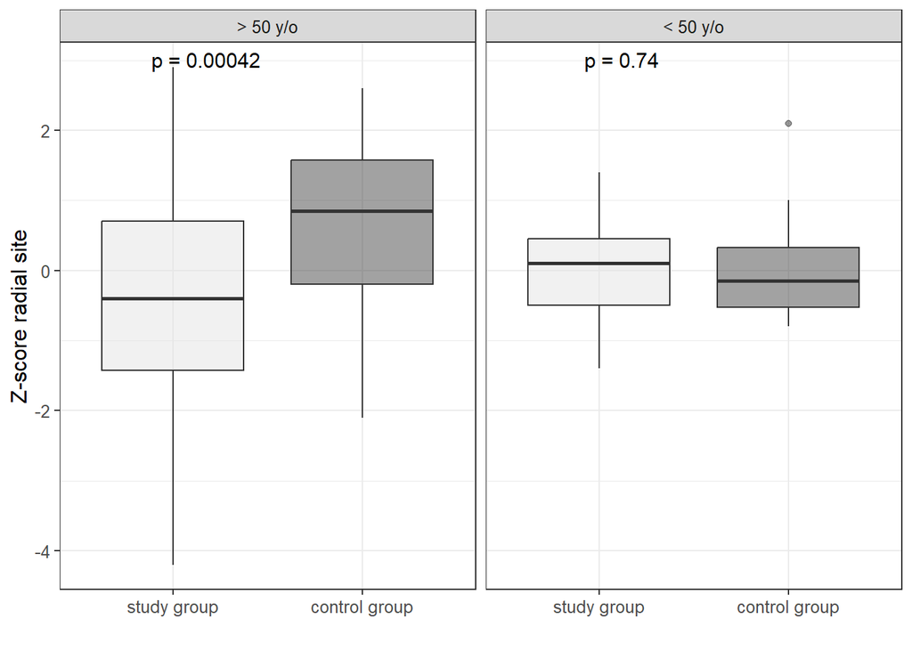

```r
ggplot(PHPT, aes(x = group, y = zscore_radial, fill = group)) +
  geom_boxplot(alpha = 0.5) +
  scale_fill_manual(values = c("gray89", "gray27"))  +
  scale_x_discrete(labels= c("study group", "control group")) +
  labs(x = " ", y = "Z-score radial site") +
  stat_compare_means(method = 't.test', label = "p.format", size = 4) +
  theme_bw() +
  theme(legend.position = "none") +
  facet_wrap(vars(age_split), labeller = labeller(age_split = c('older' = '> 50 y/o', 'younger' = '< 50 y/o'))) +
  theme(text = element_text(size = 12))
```

# Porównanie z-score radial pomiędzy grupą badaną a kontrolną z podziałem ze względu na płeć i na wiek:

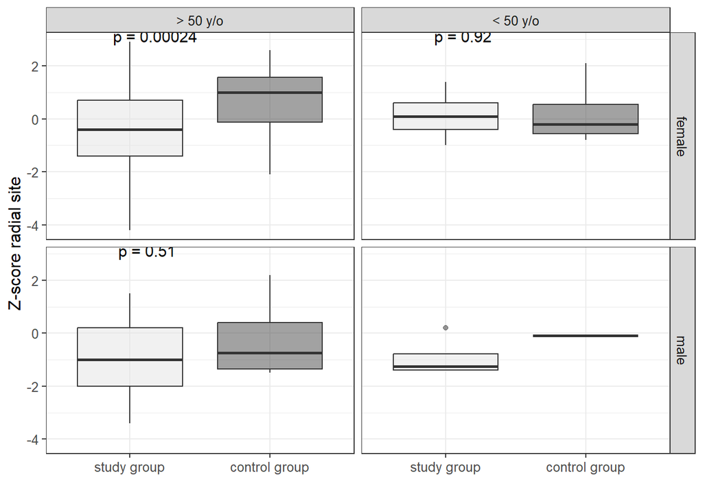

```r
ggplot(PHPT %>% filter(!is.na(zscore_radial)),
       aes(x = group, y = zscore_radial, fill = group)) +
  geom_boxplot(alpha = 0.5) +
  scale_fill_manual(values = c("gray89", "gray27"))  +
  scale_x_discrete(labels= c("study group", "control group")) +
  labs(x = " ", y = "Z-score radial site") +
  stat_compare_means(method = 't.test', label = "p.format", size = 4) +
  theme_bw() +
  theme(legend.position = "none") +
  facet_grid(sex ~ age_split,
             labeller = labeller(
               sex = c('K' = 'female', 'M' = 'male'),
               age_split = c('older' = '> 50 y/o', 'younger' = '< 50 y/o')
             )) +
  theme(text = element_text(size = 12))
```

# porownanie TBS w grupie badanej i kontrolnej:

```r
wilcox.test(TBS ~ group, data = subset(PHPT, group != "NA"))
```

```
##
##  Wilcoxon rank sum test with continuity correction
##
## data:  TBS by group
## W = 2272, p-value = 0.1101
## alternative hypothesis: true location shift is not equal to 0
```

```r
PHPT %>%
  group_by(group) %>%
  get_summary_stats(TBS, type = "quantile")
```

```
## # A tibble: 2 × 8
##   group variable     n  `0%` `25%` `50%` `75%` `100%`
##   <chr> <fct>    <dbl> <dbl> <dbl> <dbl> <dbl>  <dbl>
## 1 B     TBS        157 0.944  1.22  1.30  1.38   1.56
## 2 K     TBS         35 1.05   1.26  1.32  1.40   1.59
```

# wykres porownujacy TBS w grupie badanej i kontrolnej:

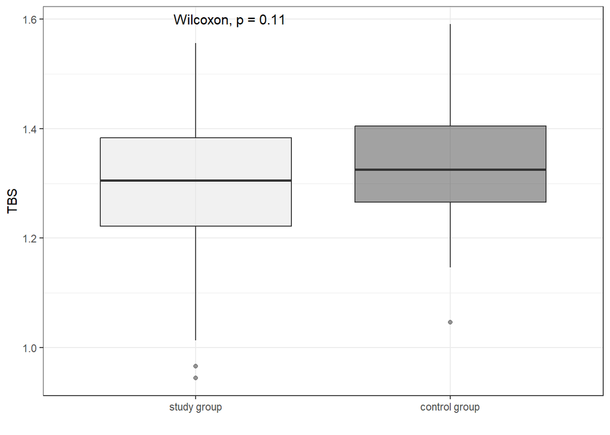

```r
ggplot(data = subset(PHPT, TBS != "NA"), aes(x = group, y = TBS, fill = group)) +
  geom_boxplot(alpha = 0.5) +
  scale_fill_manual(values = c("gray89", "gray27"))  +
  scale_x_discrete(labels= c("study group", "control group")) +
  labs(x = " ", y = "TBS") +
  stat_compare_means(method = 'wilcox.test', size = 4) +
  theme_bw() +
  theme(legend.position = "none")
```

# wykres porownujacy TBS w grupie badanej i kontrolnej z podzialem na płeć:

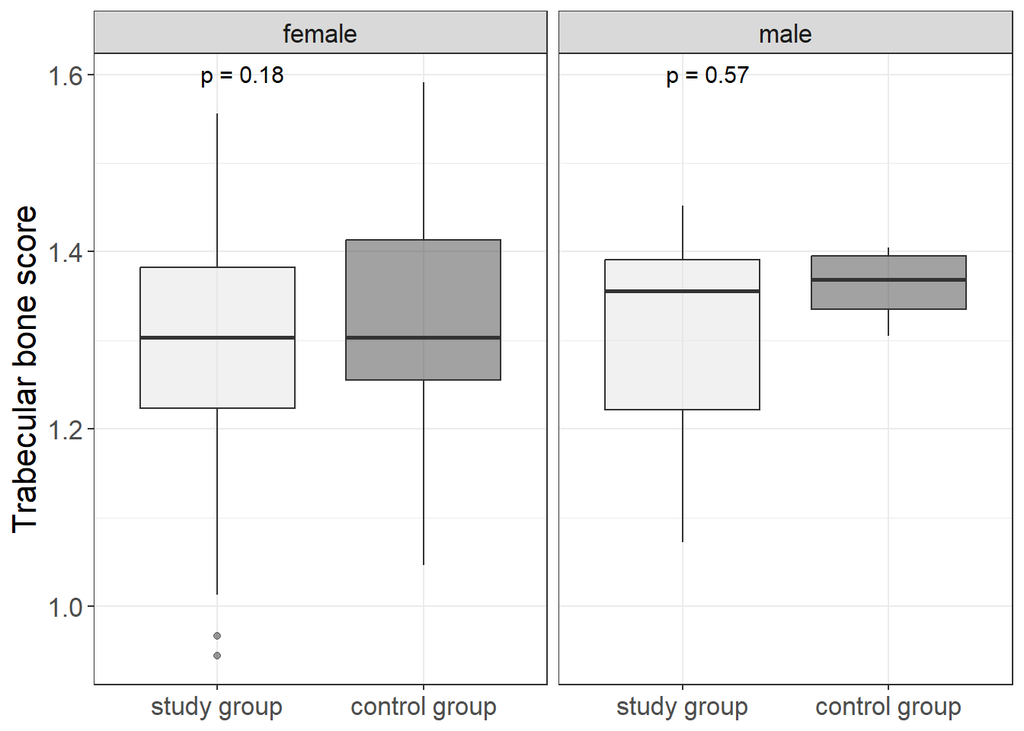

```r
ggplot(PHPT, aes(x = group, y = TBS, fill = group)) +
  geom_boxplot(alpha = 0.5) +
  scale_fill_manual(values = c("gray89", "gray27"))  +
  scale_x_discrete(labels= c("study group", "control group")) +
  labs(x = NULL, y = "Trabecular bone score") +
  stat_compare_means(method = 'wilcox.test', label = "p.format", size = 4) +
  theme_bw() +
  facet_wrap(vars(sex), labeller = labeller(sex = c('K' = 'female', 'M' = 'male'))) +
  theme(legend.position = "none") +
  theme(text = element_text(size = 16))
```

# wykres porownujacy TBS w grupie badanej i kontrolnej z podziałem na płeć i wiek przed i pomenopauzalny:

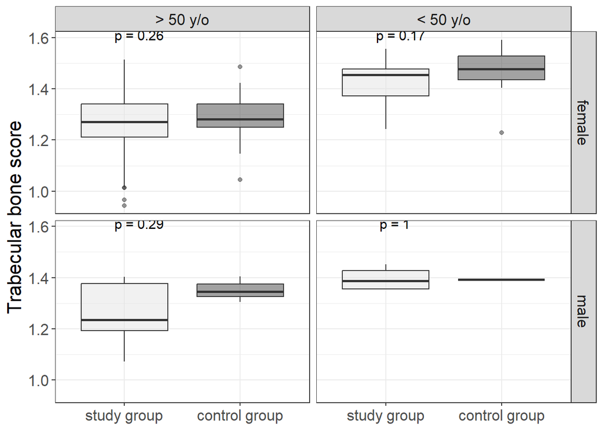

```r
ggplot(data = subset(PHPT, TBS != "NA"), aes(x = group, y = TBS, fill = group)) +
  geom_boxplot(alpha = 0.5) +
  scale_fill_manual(values = c("gray89", "gray27"))  +
  scale_x_discrete(labels= c("study group", "control group")) +
  labs(x = NULL, y = "Trabecular bone score") +
  stat_compare_means(method = 'wilcox.test', label = "p.format", size = 4) +
  theme_bw() +
  theme(legend.position = "none") +
  theme(text = element_text(size = 16)) +
  facet_grid(sex ~ age_split,
             labeller = labeller(
               sex = c('K' = 'female', 'M' = 'male'),
               age_split = c('older' = '> 50 y/o', 'younger' = '< 50 y/o')
             ))
```

# NOWE DO DOPISANIA: wykres porownujacy TBS w grupie badanej i kontrolnej pomiedzy osobami bez i ze złamaniami - w grupie osób ze złamaniami w wywiadzie stwierdzono istotnie niższe TBS w grupie PHPT:

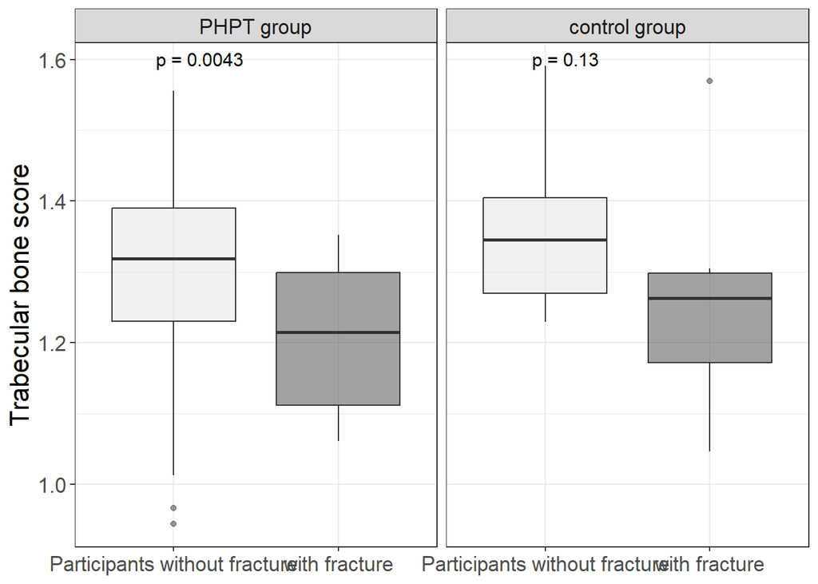

```r
ggplot(PHPT, aes(x = fracture, y = TBS, fill = fracture)) +
  geom_boxplot(alpha = 0.5) +
  scale_fill_manual(values = c("gray89", "gray27")) +
  scale_x_discrete(labels = c("Y" = "with fracture", "N" = "Participants without fracture")) +
  labs(x = NULL, y = "Trabecular bone score") +
  stat_compare_means(method = 'wilcox.test', label = "p.format", size = 4) +
  theme_bw() +
  facet_wrap(vars(group), labeller = labeller(group = c('B' = 'PHPT group', 'K' = 'control group'))) +
  theme(legend.position = "none") +
  theme(text = element_text(size = 16))
```

# TBS w grupie osób bez i z fracture

```r
PHPT_B %>%
  group_by(fracture) %>%
  get_summary_stats(TBS)
```

```
## # A tibble: 2 × 14
##   fracture variable     n   min   max median    q1    q3   iqr   mad  mean    sd
##   <chr>    <fct>    <dbl> <dbl> <dbl>  <dbl> <dbl> <dbl> <dbl> <dbl> <dbl> <dbl>
## 1 N        TBS        143 0.944  1.56   1.32  1.23  1.39 0.16  0.129  1.31 0.124
## 2 Y        TBS         14 1.06   1.35   1.22  1.11  1.30 0.188 0.148  1.21 0.104
## # ℹ 2 more variables: se <dbl>, ci <dbl>
```

# NOWE I CIKAWE DO OPISANIA: czy jest zwiazek miedzy zlamaniami w wywiadzie a TBS <1.2 i >1.2? - TAK, wychodzi, ze jest wiecej zlaman u osob z nizszym TBS niż z wyższym:

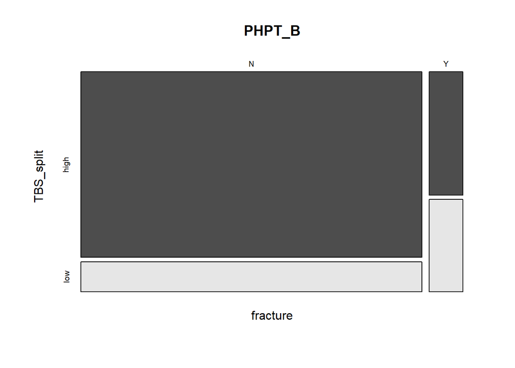

```r
mosaicplot(~ fracture + TBS_split, data = PHPT_B, color = TRUE)
```

```r
fisher.test(table(PHPT_B$fracture, PHPT_B$TBS_split))
```

```
##
##  Fisher's Exact Test for Count Data
##
## data:  table(PHPT_B$fracture, PHPT_B$TBS_split)
## p-value = 0.01382
## alternative hypothesis: true odds ratio is not equal to 1
## 95 percent confidence interval:
##   1.171033 16.852520
## sample estimates:
## odds ratio
##   4.548473
```

```r
pairwise_fisher_test(table(PHPT_B$fracture, PHPT_B$TBS_split), p.adjust.method = "fdr")
```

```
## # A tibble: 1 × 6
##   group1 group2     n      p  p.adj p.adj.signif
## * <chr>  <chr>  <int>  <dbl>  <dbl> <chr>
## 1 N      Y        157 0.0138 0.0138 *
```

```r
PHPT_B %>%
  group_by(TBS_split) %>%
  count(fracture)
```

```
## # A tibble: 6 × 3
## # Groups:   TBS_split [3]
##   TBS_split fracture     n
##   <chr>     <chr>    <int>
## 1 high      N          123
## 2 high      Y            8
## 3 low       N           20
## 4 low       Y            6
## 5 <NA>      N           31
## 6 <NA>      Y            3
```